COMBINED REPORT

# OncoProfiling Multi-Agent Analysis

Self-contained research report · generated 2026-08-22 10:57:01 EDT

Input file**uveitis-PIIS0002939421000271-deg.txt**

Workflow**biomarker**

Mapped analysis genes**137**

## Run summary

| Agent | Status | Rows | Plot |
| --- | --- | --- | --- |
| **GO** | Completed | 4 | Available |
| **KEGG** | Completed | 4 | Available |
| **REACTOME** | Completed | 4 | Available |
| **WIKIPATHWAYS** | Completed | 4 | Available |
| **HALLMARK** | Completed | 4 | Available |
| **CHEA** | Completed | 4 | Available |
| **STRING** | Completed | 8 | Available |

READ BEFORE INTERPRETING RESULTS

## Responsible interpretation

- Enrichment is over-representation and does not prove pathway activation or causality.
- Network centrality does not establish functional importance.
- GSVA scores are relative sample-level estimates; immune deconvolution is estimated composition.
- Drug-response ranks do not establish mechanism, clinical efficacy, dose, or patient suitability.
- Annotation databases and installed packages are version-dependent. Unmapped genes are excluded and reported in Methods.
- Literature novelty, clinical relevance, and target actionability require dedicated external evidence review.
- Results require independent statistical, biological, and clinical review.

PROVENANCE

## Input and run identity

[output not shown]

INTERPRETATION STATE

## Observed results and local AI

| State | Computed scientific summary |
| --- | --- |
| Source | rule |
| Model | Not recorded |
| JSON contract | 4.2-ian-evidence-integrated-report |

Observed-result bullets are computed deterministically from saved result tables. Local AI text is an interpretive layer and cannot change those observations.

IAN-STYLE INTEGRATED REVIEW

Computed scientific summary

### Executive interpretation

The synthesis layer received concise full-table summaries from 7 agents with nonempty results — GO, KEGG, REACTOME, WIKIPATHWAYS, HALLMARK, CHEA, STRING — covering 32 result rows. Cross-cutting programs detected in their result labels include cell-cycle/proliferation, EMT/extracellular matrix, growth signaling, immune/inflammation.

### Biological and cellular interpretation

The synthesis layer received concise full-table summaries from 7 agents with nonempty results — GO, KEGG, REACTOME, WIKIPATHWAYS, HALLMARK, CHEA, STRING — covering 32 result rows. Cross-cutting programs detected in their result labels include cell-cycle/proliferation, EMT/extracellular matrix, growth signaling, immune/inflammation. Recurring label-level annotations provide a starting point for integration, but related databases may repeat the same submitted genes. Member-gene overlap and unique contributions must be examined before treating agreement as independent confirmation. ChEA candidate regulator target sets are led by SOX2, SUZ12, NR3C1, STAT3. STRING connectivity candidates are led by EGFR, FN1, CD44, CDH1, IL10. These are separate prioritization layers; no direct regulator-to-hub edge, regulator activity, or causal mechanism is established by the current results.

### Detailed IAN narrative

#### Integrated biological interpretation

The evidence package contains 32 result rows from 7 nonempty agents (GO, KEGG, REACTOME, WIKIPATHWAYS, HALLMARK, CHEA, STRING). GO prioritizes response to wounding; leukocyte migration; epithelial cell proliferation. KEGG prioritizes PI3K-Akt signaling pathway; TNF signaling pathway; Focal adhesion. REACTOME prioritizes Cytokine signaling; Extracellular matrix organization; Cell junction organization. WIKIPATHWAYS prioritizes Inflammatory response; Focal adhesion; EGFR signaling. HALLMARK prioritizes EPITHELIAL_MESENCHYMAL_TRANSITION; TNFA_SIGNALING_VIA_NFKB; KRAS_SIGNALING_UP. These are complementary over-representation results from the submitted gene set; they do not measure pathway activation or establish the direction of a phenotype.

#### Evidence convergence and distinctions

Deterministic screening of the complete result-label sets identified recurring annotations related to cell-cycle/proliferation, EMT/extracellular matrix, growth signaling, immune/inflammation. This is label-level convergence used for prioritization. It does not demonstrate that the databases provide independent evidence, because related terms can share many of the same submitted genes. The pathway overlap and unique-gene tables in the report should therefore be used to distinguish repeated membership from genuinely distinct contributions.

#### Candidate regulatory and network model

ChEA prioritizes candidate regulator target sets led by SOX2, SUZ12, NR3C1, STAT3. STRING prioritizes connected proteins led by EGFR, FN1, CD44, CDH1, IL10. These regulator and network layers are not interchangeable: ChEA reflects target-set overlap, whereas STRING degree reflects retrieved network connectivity. A defensible candidate model is to test whether perturbing a ChEA-prioritized regulator changes prespecified submitted target genes and whether STRING-prioritized proteins respond in the same experiment; the current analysis does not establish those edges.

### Convergent signals

- cell-cycle/proliferation
- EMT/extracellular matrix
- growth signaling
- immune/inflammation

### Candidate regulatory network

ChEA candidate regulator target sets are led by SOX2, SUZ12, NR3C1, STAT3. STRING connectivity candidates are led by EGFR, FN1, CD44, CDH1, IL10. These are separate prioritization layers; no direct regulator-to-hub edge, regulator activity, or causal mechanism is established by the current results.

#### ChEA evidence and prioritization rationale

- SOX2 — adjusted P = 1e-30; combined score = 1507
- SUZ12 — adjusted P = 4.6e-20; combined score = 296.7
- NR3C1 — adjusted P = 3.5e-16; combined score = 139
- STAT3 — adjusted P = 2.1e-12; combined score = 92.4

ChEA enrichment indicates overlap with published regulator target sets. It does not demonstrate regulator activity in the submitted specimens.

### Hub candidates and network picture

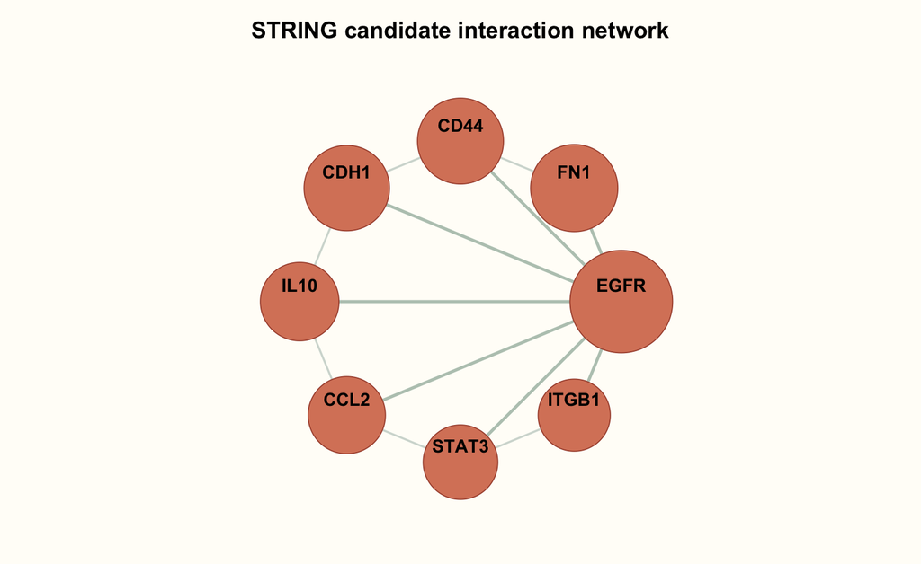

Retrieved STRING subnetwork used for connectivity ranking. Lines represent database-supported associations, not proven causal regulation.

#### Why these proteins are listed as hubs

- EGFR — interaction degree 206; prioritized by connectivity within the retrieved network.
- FN1 — interaction degree 149; prioritized by connectivity within the retrieved network.
- CD44 — interaction degree 145; prioritized by connectivity within the retrieved network.
- CDH1 — interaction degree 143; prioritized by connectivity within the retrieved network.
- IL10 — interaction degree 121; prioritized by connectivity within the retrieved network.
- CCL2 — interaction degree 117; prioritized by connectivity within the retrieved network.
- STAT3 — interaction degree 109; prioritized by connectivity within the retrieved network.
- ITGB1 — interaction degree 102; prioritized by connectivity within the retrieved network.

Degree is a network-prioritization feature. It does not prove functional importance, direction, or causality.

### Novelty and literature context

Novelty cannot be established without a dedicated, current literature review.

### Pathway member-gene overlap

**Shared member genes** are genes appearing in significant result rows from two or more pathway databases.

- CD44 (4 databases)
- CDH1 (4 databases)
- CXCL8 (4 databases)
- EGFR (4 databases)
- ERBB2 (4 databases)
- FN1 (4 databases)
- IL1B (4 databases)
- PIK3CA (4 databases)
- TNF (4 databases)

**Database-specific members**

- GO: 0 unique genes; examples: none
- KEGG: 0 unique genes; examples: none
- Reactome: 0 unique genes; examples: none
- WikiPathways: 1 unique genes; examples: TGFB1

This is a deterministic overlap of the complete saved significant-result tables. It is not independent replication and does not establish pathway activation.

### One consolidated result-grounded hypothesis

Working hypothesis: the recurring signals (cell-cycle/proliferation; EMT/extracellular matrix; growth signaling) define a coordinated gene program in which EGFR, FN1, CD44 are candidate network anchors. Test this single model in an independent biological contrast using targeted perturbation or orthogonal protein/RNA measurements, with prespecified positive and negative controls.

This is a result-grounded hypothesis for validation, not a causal or clinical conclusion.

BIOMARKER DISCOVERY

## Biomarker evidence and interpretation

Each agent shows deterministic observed results before any interpretive context.

Gene list

### GO Analysis

4 rows

Enriched Gene Ontology biological-process terms.

#### Interactive result profile

The complete full-precision result table is provided as a CSV in the downloadable results bundle.

#### Observed results · deterministic

- Coverage was calculated across all 4 result rows. Representative rows preserve each result label together with its own statistics. Aggregate numeric summaries are distribution-level information and must not be assigned to individual terms.
- All 3 numeric columns: n=12, min=1e-08, median=3.3, max=22
- p.adjust: n=4, min=1e-08, median=4.1e-05, max=0.003
- Count: n=4, min=9, median=15, max=22

#### Integrated biological interpretation

Across all 4 result rows, representative gene ontology findings include response to wounding; leukocyte migration; epithelial cell proliferation; cell adhesion. The enrichment pattern identifies coordinated biological themes represented across the submitted genes. Program-level screening across the full label set found cell-cycle/proliferation.

##### Key findings

- response to wounding
- leukocyte migration
- epithelial cell proliferation
- cell adhesion

##### Biological context

General biological context: Over-representation results organize the submitted genes into named biological processes and pathways; they support hypothesis prioritization but do not directly measure pathway activity. Cell-cycle and proliferation programs generally describe DNA replication, mitotic control, and the transcriptional machinery associated with cell division. These descriptions are general annotations of the named result labels, not additional measurements, causal conclusions, or clinical claims from this dataset.

##### Cancer relevance

These results can prioritize hypotheses for cancer-focused follow-up, but enrichment, activity, composition, network, and response outputs are associative and are not clinical evidence on their own.

Gene list

### KEGG Analysis

4 rows

Significantly enriched molecular pathways.

#### Interactive result profile

The complete full-precision result table is provided as a CSV in the downloadable results bundle.

#### Observed results · deterministic

- Coverage was calculated across all 4 result rows. Representative rows preserve each result label together with its own statistics. Aggregate numeric summaries are distribution-level information and must not be assigned to individual terms.
- All 3 numeric columns: n=12, min=1e-08, median=3.3, max=22
- p.adjust: n=4, min=1e-08, median=4.1e-05, max=0.003
- Count: n=4, min=9, median=15, max=22

#### Integrated biological interpretation

Across all 4 result rows, representative curated pathways findings include PI3K-Akt signaling pathway; TNF signaling pathway; Focal adhesion; ECM-receptor interaction. The enrichment pattern identifies coordinated biological themes represented across the submitted genes. Program-level screening across the full label set found EMT/extracellular matrix, growth signaling.

##### Key findings

- PI3K-Akt signaling pathway
- TNF signaling pathway
- Focal adhesion
- ECM-receptor interaction

##### Biological context

General biological context: Over-representation results organize the submitted genes into named biological processes and pathways; they support hypothesis prioritization but do not directly measure pathway activity. EMT and extracellular-matrix programs generally describe changes in epithelial identity, adhesion, motility, and tissue-remodeling biology. Growth-signaling programs generally describe regulatory pathways that coordinate proliferation, survival, differentiation, and environmental sensing. These descriptions are general annotations of the named result labels, not additional measurements, causal conclusions, or clinical claims from this dataset.

##### Cancer relevance

These results can prioritize hypotheses for cancer-focused follow-up, but enrichment, activity, composition, network, and response outputs are associative and are not clinical evidence on their own.

Gene list

### Reactome Analysis

4 rows

Curated pathway enrichment.

#### Interactive result profile

The complete full-precision result table is provided as a CSV in the downloadable results bundle.

#### Observed results · deterministic

- Coverage was calculated across all 4 result rows. Representative rows preserve each result label together with its own statistics. Aggregate numeric summaries are distribution-level information and must not be assigned to individual terms.
- All 3 numeric columns: n=12, min=1e-08, median=3.3, max=22
- p.adjust: n=4, min=1e-08, median=4.1e-05, max=0.003
- Count: n=4, min=9, median=15, max=22

#### Integrated biological interpretation

Across all 4 result rows, representative curated pathways findings include Cytokine signaling; Extracellular matrix organization; Cell junction organization; Growth factor signaling. The enrichment pattern identifies coordinated biological themes represented across the submitted genes. Program-level screening across the full label set found immune/inflammation, EMT/extracellular matrix.

##### Key findings

- Cytokine signaling
- Extracellular matrix organization
- Cell junction organization
- Growth factor signaling

##### Biological context

General biological context: Over-representation results organize the submitted genes into named biological processes and pathways; they support hypothesis prioritization but do not directly measure pathway activity. Immune and inflammatory programs generally describe cytokine signaling, leukocyte-associated responses, and host-defense processes. EMT and extracellular-matrix programs generally describe changes in epithelial identity, adhesion, motility, and tissue-remodeling biology. These descriptions are general annotations of the named result labels, not additional measurements, causal conclusions, or clinical claims from this dataset.

##### Cancer relevance

These results can prioritize hypotheses for cancer-focused follow-up, but enrichment, activity, composition, network, and response outputs are associative and are not clinical evidence on their own.

Gene list

### WikiPathways Analysis

4 rows

Community pathway enrichment.

#### Interactive result profile

The complete full-precision result table is provided as a CSV in the downloadable results bundle.

#### Observed results · deterministic

- Coverage was calculated across all 4 result rows. Representative rows preserve each result label together with its own statistics. Aggregate numeric summaries are distribution-level information and must not be assigned to individual terms.
- All 3 numeric columns: n=12, min=1e-08, median=3.3, max=22
- p.adjust: n=4, min=1e-08, median=4.1e-05, max=0.003
- Count: n=4, min=9, median=15, max=22

#### Integrated biological interpretation

Across all 4 result rows, representative community pathways findings include Inflammatory response; Focal adhesion; EGFR signaling; TGF-beta signaling. The enrichment pattern identifies coordinated biological themes represented across the submitted genes. Program-level screening across the full label set found immune/inflammation, EMT/extracellular matrix, growth signaling.

##### Key findings

- Inflammatory response
- Focal adhesion
- EGFR signaling
- TGF-beta signaling

##### Biological context

General biological context: Over-representation results organize the submitted genes into named biological processes and pathways; they support hypothesis prioritization but do not directly measure pathway activity. Immune and inflammatory programs generally describe cytokine signaling, leukocyte-associated responses, and host-defense processes. EMT and extracellular-matrix programs generally describe changes in epithelial identity, adhesion, motility, and tissue-remodeling biology. Growth-signaling programs generally describe regulatory pathways that coordinate proliferation, survival, differentiation, and environmental sensing. These descriptions are general annotations of the named result labels, not additional measurements, causal conclusions, or clinical claims from this dataset.

##### Cancer relevance

These results can prioritize hypotheses for cancer-focused follow-up, but enrichment, activity, composition, network, and response outputs are associative and are not clinical evidence on their own.

Gene list

### Hallmark Analysis

4 rows

Cancer hallmark gene-set enrichment.

#### Interactive result profile

The complete full-precision result table is provided as a CSV in the downloadable results bundle.

#### Observed results · deterministic

- Coverage was calculated across all 4 result rows. Representative rows preserve each result label together with its own statistics. Aggregate numeric summaries are distribution-level information and must not be assigned to individual terms.
- All 3 numeric columns: n=12, min=1e-08, median=3.3, max=22
- p.adjust: n=4, min=1e-08, median=4.1e-05, max=0.003
- Count: n=4, min=9, median=15, max=22

#### Integrated biological interpretation

Across all 4 result rows, representative cancer hallmark gene sets findings include EPITHELIAL_MESENCHYMAL_TRANSITION; TNFA_SIGNALING_VIA_NFKB; KRAS_SIGNALING_UP; INFLAMMATORY_RESPONSE. The enrichment pattern identifies coordinated biological themes represented across the submitted genes. Program-level screening across the full label set found immune/inflammation, EMT/extracellular matrix.

##### Key findings

- EPITHELIAL_MESENCHYMAL_TRANSITION
- TNFA_SIGNALING_VIA_NFKB
- KRAS_SIGNALING_UP
- INFLAMMATORY_RESPONSE

##### Biological context

General biological context: Over-representation results organize the submitted genes into named biological processes and pathways; they support hypothesis prioritization but do not directly measure pathway activity. Immune and inflammatory programs generally describe cytokine signaling, leukocyte-associated responses, and host-defense processes. EMT and extracellular-matrix programs generally describe changes in epithelial identity, adhesion, motility, and tissue-remodeling biology. These descriptions are general annotations of the named result labels, not additional measurements, causal conclusions, or clinical claims from this dataset.

##### Cancer relevance

These results can prioritize hypotheses for cancer-focused follow-up, but enrichment, activity, composition, network, and response outputs are associative and are not clinical evidence on their own.

Gene list

### ChEA Analysis

4 rows

Candidate transcription-factor regulators.

#### Interactive result profile

The complete full-precision result table is provided as a CSV in the downloadable results bundle.

#### Observed results · deterministic

- Coverage was calculated across all 4 result rows. Representative rows preserve each result label together with its own statistics. Aggregate numeric summaries are distribution-level information and must not be assigned to individual terms.
- All 2 numeric columns: n=8, min=1e-30, median=46.2, max=1507
- Adjusted.P.value: n=4, min=1e-30, median=1.75e-16, max=2.1e-12
- Combined.Score: n=4, min=92.4, median=217.8, max=1507

#### Integrated biological interpretation

Across all 4 result rows, representative transcriptional regulation findings include SOX2 20726797 ChIP-Seq SW620 Human; SUZ12 20007587 ChIP-Seq Mouse; NR3C1 27076634 ChIP-Seq BEAS2B Human; STAT3 23264808 ChIP-Seq Human. The enrichment pattern highlights candidate transcriptional regulators represented across the submitted gene program. Program-level screening across the full label set found no predefined cross-cutting program.

##### Key findings

- SOX2 20726797 ChIP-Seq SW620 Human
- SUZ12 20007587 ChIP-Seq Mouse
- NR3C1 27076634 ChIP-Seq BEAS2B Human
- STAT3 23264808 ChIP-Seq Human

##### Biological context

General biological context: ChEA enrichment identifies transcription-factor target sets that overlap the submitted genes; it prioritizes candidate regulators but does not directly measure regulator expression, binding, or activity. These descriptions are general annotations of the named result labels, not additional measurements, causal conclusions, or clinical claims from this dataset.

##### Cancer relevance

These results can prioritize hypotheses for cancer-focused follow-up, but enrichment, activity, composition, network, and response outputs are associative and are not clinical evidence on their own.

Gene list

### STRING Analysis

8 rows

Protein interaction network and hub ranking.

#### Connected 3D STRING interaction network

NETWORK GUIDE

#### How to read this view

**8**ranked nodes considered

- **Balls** are submitted proteins ranked by STRING interaction degree.
- **Lines** are retrieved STRING associations among displayed proteins; they are not directional regulatory arrows.
- **Size and colour** encode interaction degree within the retrieved network.

##### Highest-degree hubs

1. EGFR**206 degree**
2. FN1**149 degree**
3. CD44**145 degree**
4. CDH1**143 degree**
5. IL10**121 degree**
6. CCL2**117 degree**

##### Mouse controls

**Drag** to rotate · **scroll** to zoom · **hover** for exact degree and edge scores · **double-click** to reset.

**Interpret carefully:** connectivity prioritizes candidates; it does not prove activity, functional importance, direction, or causality.

The complete full-precision result table is provided as a CSV in the downloadable results bundle.

#### Observed results · deterministic

- Coverage was calculated across all 8 result rows. Representative rows preserve each result label together with its own statistics. Aggregate numeric summaries are distribution-level information and must not be assigned to individual terms.
- All 1 numeric columns: n=8, min=102, median=132, max=206
- degree: n=8, min=102, median=132, max=206

#### Integrated biological interpretation

Across all 8 result rows, representative protein interaction network findings include EGFR; FN1; CD44; CDH1; IL10. The ranking highlights connected proteins in the retrieved interaction network. Program-level screening across the full label set found no predefined cross-cutting program.

##### Key findings

- EGFR
- FN1
- CD44
- CDH1
- IL10
- CCL2

##### Biological context

General biological context: Protein-interaction connectivity summarizes relationships represented in the retrieved STRING network; hub position is a prioritization feature rather than proof of causal biological control. These descriptions are general annotations of the named result labels, not additional measurements, causal conclusions, or clinical claims from this dataset.

##### Cancer relevance

These results can prioritize hypotheses for cancer-focused follow-up, but enrichment, activity, composition, network, and response outputs are associative and are not clinical evidence on their own.

METHODS, MAPPING, AND VERSIONS

## Reproducible methods

**Interpretation method.** The local prompt adapts Dr. Tyc's IAN combined-review sequence: individual-agent review, pathway integration, groundedness checking, regulator/network assessment, one consolidated hypothesis, validation planning, and high-level synthesis. Literature similarity and novelty are not asserted without a dedicated literature review.

### Gene mapping summary

| Identifier type | ENSEMBL |
| --- | --- |
| Unique inputs | 180 |
| Mapped inputs | 137 |
| Unique HGNC symbols | 137 |
| Unmapped inputs | 43 |
| Mapping rate | 76.1% |
| Duplicate mappings removed | 0 |
| Unmapped examples | ENSG00000231535, ENSG00000223972 |

### Input selection and experimental context

| Experimental design / comparison | Uveitis DEG list; case/control contrast details were not supplied in the one-column source file. |
| --- | --- |
| Detected gene column | gene |
| Detected adjusted p/FDR column | Not recorded |
| Detected effect-size column | Not recorded |
| Genes before selection | 180 |
| Selection rule | All unique mapped identifiers were used because no adjusted-p or effect-size columns were present. |
| Gene group | all |
| Protein-coding only | FALSE |
| Adjusted p/FDR cutoff | 0.05 |
| Absolute effect cutoff | 1 |
| Maximum genes | 2000 |
| Tested gene universe | Not supplied; agent/package defaults were used. |

### Analysis environment

Human identifier mapping uses the installed org.Hs.eg.db annotation. Enrichment statistics, multiple-testing values, and database-specific identifiers are retained in the complete CSV artifacts. Where no tested-gene universe was supplied, the relevant package or annotation collection default was used; this limits comparability across databases. Interactive horizontal bar charts are descriptive views of recorded result metrics.

| component | version |
| --- | --- |
| R | 4.6.1 |
| shiny | 1.14.0 |
| clusterProfiler | 4.20.0 |
| org.Hs.eg.db | 3.23.1 |
| ReactomePA | 1.56.0 |
| STRINGdb | 2.24.0 |
| msigdbr | 26.1.0 |
| GSVA | 2.6.2 |
| immunedeconv | 2.1.4 |
| ggplot2 | 4.0.3 |
| plotly | 4.12.0 |
| htmlwidgets | 1.6.4 |
| jsonlite | 2.0.0 |
| httr2 | 1.3.0 |

ARTIFACT MANIFEST

## Files represented in this report

| agent | artifact | file | exists | size_bytes | md5 | rows |
| --- | --- | --- | --- | --- | --- | --- |
| go | csv | go.csv | TRUE | 275.00 | f7e5367223d57f923e027dfc8518692a | 4.00 |
| go | plot | go_biological_process_dotplot.png | TRUE | 227,866.00 | d178ca27e110d9d2967e62368b585f98 |  |
| kegg | csv | kegg.csv | TRUE | 271.00 | b4201f852399e1d8ca9d38e6bef35c1b | 4.00 |
| kegg | plot | kegg_pathway_dotplot.png | TRUE | 237,004.00 | 61a72f317d66a66bbf33c48280a86541 |  |
| reactome | csv | reactome.csv | TRUE | 296.00 | a99fb808edd7249614eb2d8082db3065 | 4.00 |
| reactome | plot | reactome_pathways.png | TRUE | 256,665.00 | af23d1c500dd8713be534bb1c796aba4 |  |
| wikipathways | csv | wikipathways.csv | TRUE | 244.00 | 4d9e26de0e3a49bef7cca35313ab7a52 | 4.00 |
| wikipathways | plot | wikipathways_pathways.png | TRUE | 200,894.00 | cd6d6bb16bf9382fed8051331984d62b |  |
| hallmark | csv | hallmark.csv | TRUE | 299.00 | 52f24513414e3c708fce2461d4e7dacd | 4.00 |
| hallmark | plot | hallmark_pathways.png | TRUE | 161,569.00 | cabc83773956598ffe5e0fe0ec12f66f |  |
| chea | csv | chea.csv | TRUE | 270.00 | ae78e32fca5a589c05a6fa721fb8bfcb | 4.00 |
| chea | plot | chea_tf_dotplot.png | TRUE | 318,685.00 | e3ab820a85a0ccf012039b841ada42d0 |  |
| string | csv | string.csv | TRUE | 238.00 | 933b7936ae2aeed1d8d89425829cb954 | 8.00 |
| string | plot | string_network.png | TRUE | 113,289.00 | 5019b33f37597d0bd907759f909c3ae1 |  |
| string | interactions | string_interactions.csv | TRUE | 189.00 | 11ead21c521295224a79439235e1b695 |  |